[figure not shown]

### Ensimag 2A

# Optimisation Numérique

## TP: Algorithmes de descente de gradient et (quasi-) Newton

# Introduction

L'objectif de ce TP est de se familiariser avec les algorithmes d'optimisation numérique en codant deux algorithmes de base et en observant leur comportement sur deux fonctions simples.

L’ensemble d’un programme d'optimisation se présente en deux parties :

- *un simulateur :* il est chargé de calculer la fonction (ainsi que le gradient et éventuellement la Hessienne) en chaque point décidé par l’algorithme. Souvent, la fonction à minimiser n’est connue que via ce simulateur.
- *l’algorithme proprement dit :* il comporte dans notre cas deux boîtes principales correspondant au calcul de la direction, et au calcul du pas.

En pratique, nous allons séparer *simulateurs* et *partie algorithmique* de la manière suivante :

- `TP.ipynb`, le présent fichier, contiendra l'énoncé, les algorithmes développés, et sera l'environnement d'éxécution et d'affichage
- `sim_f1.ipynb` `sim_f2.ipynb` contiendront les simulateurs des fonctions étudiées.

Afin de pouvoir importer les simulateurs, sous la forme de *notebooks*, de la même manière que des scripts python, le script suivant est nécessaire. Aussi, à chaque modification des simulateurs, il est nécessaire de les recharger à l'aide de la fonction `reload`.

```python
import start
from importlib import reload
```

**Example d'import d'un simulateur :**

```python
import sim_f1 as f1
reload(f1)
```

```
importing notebook from sim_f1.ipynb
importing notebook from sim_f1.ipynb
```

```
<module 'sim_f1' from 'sim_f1.ipynb'>
```

## Exercice 1. Simulateurs

> Ecrire dans les fichiers respectifs `sim_f1.ipynb` et `sim_f2.ipynb` un simulateur pour les fonctions suivantes : $$\begin{array}{rl} f_1(x) =& \sum_{k=1}^n k x_k^2 ~~~ \text{ pour } x\in\mathbb{R}^n\\ f_2(x) =& (1-x_1)^2 + 100(x_2-x_1^2)^2 ~~~ \text{ pour } x=(x_1,x_2)\in\mathbb{R}^2\end{array}$$

Le format du simulateur doit etre

```python
def sim(x):
    # Calcul de la valeur de la fonction et de son gradient en x
    return f,g
```

avec `x` la valeur de la variable pour laquelle il faut évaluer $f$ et son gradient, `f` qui vaut $f(x)$ et `g` qui vaut $\nabla f(x)$.

## Exercice 2. Lignes de niveaux et plot 3D

> Visualiser la géométrie des lignes de niveaux ainsi que le tracé 3D de la fonction pour $f_1$ avec $n=2$ et $f_2$ à l'aide des fonctions `level_plot` and `custom_3dplot`. Les paramètres de ces tracés peuvent être changés dans les fichiers des simulateurs respectifs. Discuter la convexité des deux fonctions.

#### Fonction $f_1$

```
importing notebook from sim_f1.ipynb
```

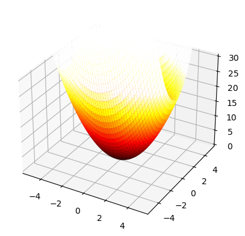

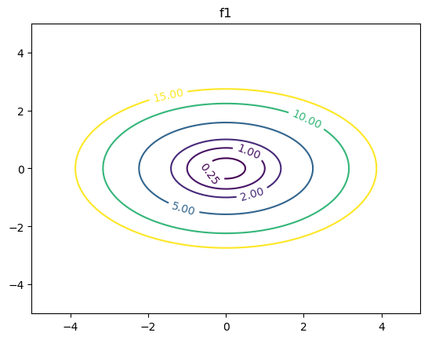

```python
from plotLib import *
%matplotlib inline

import sim_f1 as f1
reload(f1)


custom_3dplot( f1.sim, f1.x1_min,f1.x1_max,f1.x2_min,f1.x2_max,f1.nb_points, f1.vmin, f1.vmax )
level_plot( f1.sim, f1.x1_min,f1.x1_max,f1.x2_min,f1.x2_max,f1.nb_points, f1.levels , f1.title )
```

On a $\forall 0 \leq i \leq n$

$\frac{d^2}{dx_i^2}f(x) = \frac{d^2}{dx_i^2} \left( \sum_{k=1}^n k x_k^2 \right) = \sum_{k=1}^n \frac{d^2}{dx_i^2} (k x_k^2) = 2i$

Puisque i est positive, $\forall i \leq n$, $\frac{d^2}{dx_i^2}f(x)$ est positive.

Donc la fonction $f_1$ est convexe

#### Fonction $f_2$

```
importing notebook from sim_f2.ipynb
importing notebook from sim_f2.ipynb
```

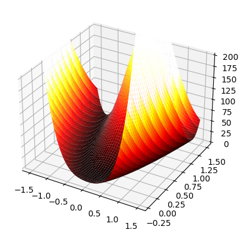

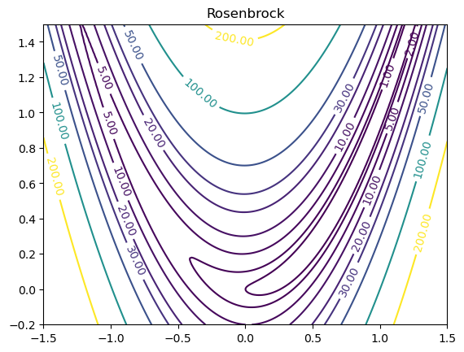

```python
from plotLib import *
%matplotlib inline

import sim_f2 as f2
reload(f2)


custom_3dplot( f2.sim, f2.x1_min,f2.x1_max,f2.x2_min,f2.x2_max,f2.nb_points, f2.vmin, f2.vmax )
level_plot( f2.sim, f2.x1_min,f2.x1_max,f2.x2_min,f2.x2_max,f2.nb_points, f2.levels , f2.title )
```

La fonction f2 n'est pas convexe.

Nous pouvons utiliser le fait que si une fonction est convexe, alors le segment de droite reliant deux points sur la surface de la fonction doit se trouver entièrement au-dessus de la surface.

Or nous pouvons voir que graphiquement certain segment reliant deux point sur la surface se trouve en dessous de la surface

En effet

Or 121 > 5

Donc la fonction $f_2$ n'est pas convexe

## Exercice 3. Algorithme de gradient à pas constant

Commençons par un algorithme de descente simple : la méthode du gradient à pas constant. À chaque itération, on fixe deux choses : la direction de descente $d = -\nabla f(x)$ et le pas $\gamma>0$, la méthode s'écrit alors $$ x_{k+1} = x_k - \gamma \nabla f(x_k). $$

> Créer une fonction qui prendra en entrée
> - `sim` le nom du simulateur
> - `x0` le point initial
> - `gamma` le pas (constant)
> - `PREC` la précision attendue (la norme du gradient au point final souhaitée)
> - `ITE_MAX` le nombre maximal d'itérations à faire

> Retourner le point final, ainsi que le tableau $k\times n$ des iterées où $k$ est le nombre d'itérations effectuées.

```python
import numpy as np
import timeit
import math
def gradient_algorithm(sim , x0 , gamma , PREC , ITE_MAX ):
    x = np.copy(x0)
    x_tab = np.copy(x)
    f,g =  sim(x0)
    ####################
    k=0
    while k < ITE_MAX and np.linalg.norm(g) > PREC:
        x = x - gamma*g
        x_tab = np.vstack((x_tab,x)) # you may build x_tab by stacking vertically current x values
        if(x[0] == float("NaN") or x[1]  == float("NaN") or abs(x[0]) == math.inf or abs(x[-1]) == math.inf):
            return None,None,-1
        f,g = sim(x)
        k+=1
    ####################
    return x,x_tab,k
```

Appliquer l'algorithme précédent pour minimiser $f_1$ en dimension 2 à partir de $x_0 = (-1,-1)$.

> Tester plusieurs pas de descente : $\gamma = 0.1$, puis $\gamma = 0.5$, et $\gamma=1$.

> Tester ensuite en dimension supérieure.

```python
from plotLib import *
%matplotlib inline

import sim_f1 as f1
reload(f1)
f1.n = 2

#### Parameter we give at our algorithm
PREC    = 0.0001                      # Sought precision
ITE_MAX = 100                         # Max number of iterations
x0      = np.array( [-1.0 , -1.0] )  # Initial point
gamma   =  0.1                       # Stepsize

x,x_tab,nb_iter =  gradient_algorithm(f1.sim , x0 , gamma , PREC , ITE_MAX )
```

```
importing notebook from sim_f1.ipynb
```

> Dans le cas $n=2$, tracer les itérées sur les lignes de niveau de la fonction par la fonction `level_points_plot`.

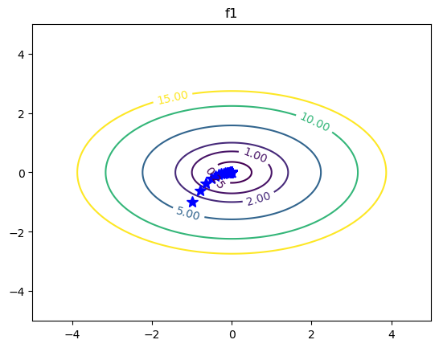

```
the minimum is at ( -4.3556142965880136e-05 , -1.0394563753404872e-10 ).
the algorithm converge in 45 iterations.
```

```python
from plotLib import *
%matplotlib inline

level_points_plot( f1.sim , x_tab ,f1.x1_min,f1.x1_max,f1.x2_min,f1.x2_max,f1.nb_points, f1.levels , f1.title )
print("the minimum is at (",x[0], ",", x[1], ").")
print("the algorithm converge in", nb_iter, "iterations.")
```

L'algorithme trouve bien le minimum en $(0,0)$

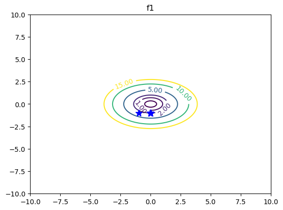

```
the minimum is at ( 0.0 , -1.0 ).
the algorithm converge in 100 iterations.
```

```python
gamma   =  0.5
x,x_tab,nb_iter =  gradient_algorithm(f1.sim , x0 , gamma , PREC , ITE_MAX )

from plotLib import *
%matplotlib inline

level_points_plot( f1.sim , x_tab ,2*f1.x1_min,2*f1.x1_max,2*f1.x2_min,2*f1.x2_max,f1.nb_points, f1.levels , f1.title )
print("the minimum is at (",x[0], ",", x[1], ").")
print("the algorithm converge in", nb_iter, "iterations.")
```

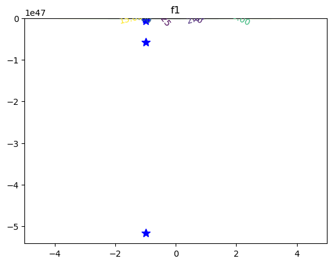

```
the minimum is at ( -1.0 , -5.153775207320113e+47 ).
the algorithm converge in 100 iterations.
```

```python
gamma   =  1
x,x_tab,nb_iter =  gradient_algorithm(f1.sim , x0 , gamma , PREC , ITE_MAX )

from plotLib import *
%matplotlib inline

level_points_plot( f1.sim , x_tab ,f1.x1_min,f1.x1_max,f1.x2_min,f1.x2_max,f1.nb_points, f1.levels , f1.title )
print("the minimum is at (",x[0], ",", x[1], ").")
print("the algorithm converge in", nb_iter, "iterations.")
```

```python
import matplotlib.pyplot as plt

ITE_MAX = 8000

def speed_test(gamma_min, gamma_max):
    step = 0.01
    gamma_list = [gamma_min]
    speed = []
    while gamma_min <= gamma_list[-1] <= gamma_max:
        x,_,nb_iter =  gradient_algorithm(f1.sim , x0 , gamma_list[-1] , PREC , ITE_MAX )
        if(x is None):
            speed.append(-1)
        else:
            speed.append(nb_iter)

        gamma_list.append(gamma_list[-1]+step)


    plt.plot([gamma_list[i] for i in range(len(speed)) if speed[i] == -1], [speed[i] for i in range(len(speed)) if speed[i] == -1], "xb")
    plt.plot([gamma_list[i] for i in range(len(speed)) if speed[i] != -1], [speed[i] for i in range(len(speed)) if speed[i] != -1], "--r")
    plt.title("Nombre d'itérations en fonction de gamma.")
    plt.xlabel("Valeur de gamma")
    plt.ylabel("Nombre d'itérations")
    segment = [gamma_list[i] for i in range(len(speed)) if speed[i] != -1]
    print("Un gamma dans [", segment[0], ", ", segment[-1], "] semblent faire converger l'algorithme.")
    print("Le nombre minimal d'itérations dans les cas convergents est ", min ([speed[i] for i in range(len(speed)) if speed[i] != -1]), ".")
```

```
Un gamma dans [ 0.001 ,  0.5210000000000002 ] semblent faire converger l'algorithme.
Le nombre minimal d'itérations dans les cas convergents est  10 .
```

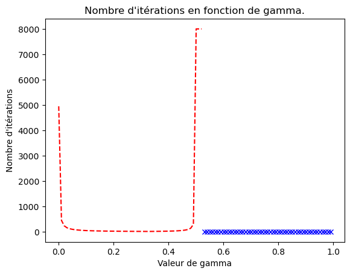

```python
speed_test(0.001, 1)
```

Nous avons testé l'algorithme avec des valeurs de $\gamma$ comprisent dans $[0.001, 1]$. Les points en bleu sontles valeurs de de $\gamma$ qui ont fait divergé l'algorithme, les rouges sont ont pour ordonnées le nombre d'itérations effectué avant qu'une des conditions d'arrêt soientt remplies. On remarque que la valeur de $\gamma$ qui permet une convergence de l'algorithme est limitée. Ici elle semble être dans un intervalle $]0, \gamma_{max}[$ avec $\gamma_{max}$ au voisinage de $0.521$

De plus si un pas trop petit va ralentir la vitesse de convergence, un pas trop grand risque aussi de ralentir, car les sauts successifs seront trop grossier, voire de faire diverger l'algortihme. On constate donc qu'il y a bien une notion de "pas optimale".

De même pour minimiser $f_2$ :

> Expérimenter différents paramètres à partir de $x_0= (-1,1.2)$.

```python
from plotLib import *
%matplotlib inline

import sim_f2 as f2
reload(f2)


#### Parameter we give at our algorithm
PREC    = 0.0001                     # Sought precision
ITE_MAX = 10000                      # Max number of iterations
x0      = np.array( [ -1 , 1.2] )    # Initial point
gamma   = 0.001                      # Stepsize

x,x_tab,nb_iter =  gradient_algorithm(f2.sim , x0 , gamma , PREC , ITE_MAX )
```

```
importing notebook from sim_f2.ipynb
```

> Tracer les itérées sur les lignes de niveau de la fonction par la fonction `level_points_plot`.

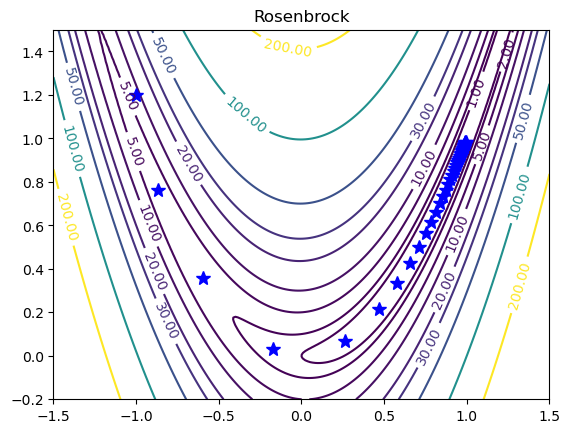

```
the minimum is at ( 0.9921682101507165 , 0.9843662695962672 ).
the algorithm converge in 10000 iterations.
```

```python
from plotLib import *
%matplotlib inline

level_points_plot( f2.sim , x_tab ,f2.x1_min,f2.x1_max,f2.x2_min,f2.x2_max,f2.nb_points, f2.levels , f2.title )
print("the minimum is at (",x[0], ",", x[1], ").")
print("the algorithm converge in", nb_iter, "iterations.")
```

L'algorithme converge bien vers le minimum qui se trouve en $(1,1)$ .

```python
import matplotlib.pyplot as plt

ITE_MAX = 100000
PREC    = 0.001

def speed_test(gamma_min, gamma_max):
    step = 0.0001
    gamma_list = [gamma_min]
    speed = []
    while gamma_min <= gamma_list[-1] <= gamma_max:
        x,_,nb_iter =  gradient_algorithm(f2.sim , x0 , gamma_list[-1] , PREC , ITE_MAX )
        if(x is None):
            speed.append(-1)
        else:
            speed.append(nb_iter)


        gamma_list.append(gamma_list[-1]+step)


    plt.plot([gamma_list[i] for i in range(len(speed)) if speed[i] == -1], [speed[i] for i in range(len(speed)) if speed[i] == -1], "xb")
    plt.plot([gamma_list[i] for i in range(len(speed)) if speed[i] != -1], [speed[i] for i in range(len(speed)) if speed[i] != -1], "--r")
    plt.title("Nombre d'itérations en fonction de gamma.")
    plt.xlabel("Valeur de gamma")
    plt.ylabel("Nombre d'itérations")
    segment = [gamma_list[i] for i in range(len(speed)) if speed[i] != -1]
    print("Un gamma dans [", segment[0], ", ", segment[-1], "] semblent faire converger l'algorithme.")
    print("Le nombre minimal d'itérations dans les cas convergents est ", min ([speed[i] for i in range(len(speed)) if speed[i] != -1]), ".")
```

```
Un gamma dans [ 0.0001 ,  0.004199999999999998 ] semblent faire converger l'algorithme.
Le nombre minimal d'itérations dans les cas convergents est  7365 .
```

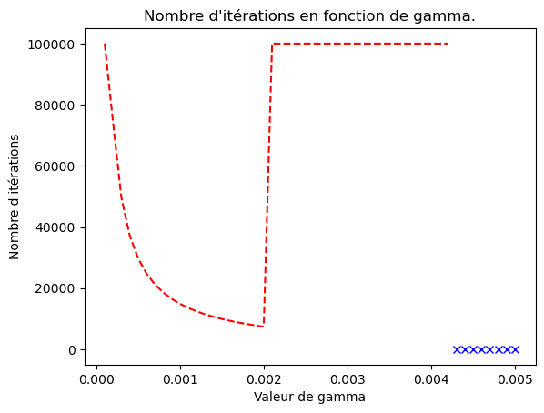

```python
speed_test(0.0001, 0.005)
```

On constate ici le même phénomène que pécédement. On constate encore un intervalle sur lequel le choix de $\gamma$ fait converger l'algorithme. On remarque que pour ce problème le nombre d'itérations peut augmenter très frotement, pour certaine valeur de gamma un critère d'arrête de $100000$ itérations n'est pas suffisant. Le nombre d'itérations minimal est plus élevé que pour le problème précédent, ce qui est du à la fonction à minimiser.

## Exercice 4. Recherche linéaire

La question précendente montre la difficulté de choisir un bon pas de descente.

Une manière de choisir un pas $\gamma$ satisfaisant est de tester différents pas en appellant plusieurs fois le simulateur. Cette procédure s'appelle recherche linéaire ; la recherche linéaire de Wolfe est implémentée dans la fonction `Wolfe_line_search` fournie dans la bibliothèque `custom_optim` ci-jointe.

**`function`** *Wolfe_line_search(sim,xk,pk)*

- Input:
  - `sim` a function simulator
  - `xk` the current point
  - `pk` the current descent direction
- Output:
  - `alpha` an admissible stepsize satisfying Wolfe conditions (`double`) or `None` if the method did not converge

**Méthode de Wolfe.** Soit un point $x$, une direction de descente $d$, et $q(t)=f(x+\gamma d)$. La recherche linéaire de Wolfe consiste à decider que

- $\gamma$ est satisfaisant si $q(t)\leq q(0)+m_1 \gamma q'(0)$ et $q'(t)\geq m_2 q'(0)$;
- $\gamma$ est trop grand si $q(t) > q(0)+m_1 \gamma q'(0)$;
- $\gamma$ est trop petit si $q(t)\leq q(0)+m_1 \gamma q'(0)$ et $q'(t)<m_2 q'(0)$;

pour deux constantes $0<m_1<m_2<1$, par exemple : $m1 = 0.1, m2 = 0.9$.

> Ecrire un algorithme de gradient avec cette recherche linéaire. Le tester sur $f_2$.

```python
import custom_optim
reload(custom_optim)
from custom_optim import Wolfe_line_search


import numpy as np
import timeit

def gradient_ls(sim , x0 , PREC , ITE_MAX ):
    x = np.copy(x0)
    x_tab = np.copy(x)
    f,g =  sim(x0)
    ####################
    # A COMPLETER
    k=0
    while k < ITE_MAX and np.linalg.norm(g) > PREC:
        gamma = Wolfe_line_search(sim,x,-g)
        if(gamma is None):
            print("method did not converge.")
            break

        x = x - gamma*g
        x_tab = np.vstack((x_tab,x)) # you may build x_tab by stacking vertically current x values
        f,g = sim(x)
        k+=1
    ####################
    return x,x_tab,k
```

```python
from plotLib import *
%matplotlib inline

import sim_f2 as f2
reload(f2)


#### Parameter we give at our algorithm
PREC    = 0.0001                     # Sought precision
ITE_MAX = 10000                      # Max number of iterations
x0      = np.array( [ -1 , 1.2] )    # Initial point
gamma   = 0.001                      # Stepsize

x,x_tab,nb_iter =  gradient_ls(f2.sim , x0 , PREC , ITE_MAX )
```

```
importing notebook from sim_f2.ipynb
```

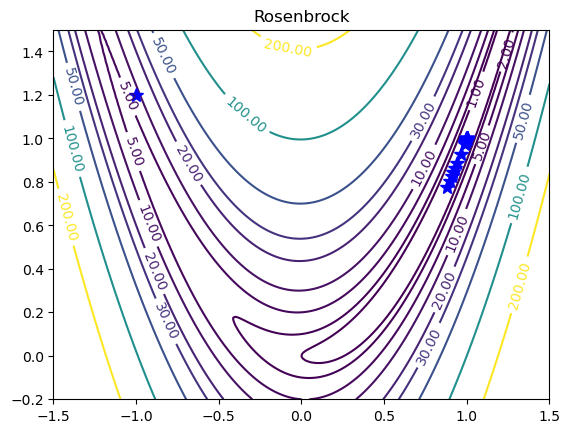

```
the minimum is at ( 0.9998996236779578 , 0.9997989541665722 ).
the algorithm converge in 4343 iterations.
```

```python
import plotLib
reload(plotLib)
from plotLib import *
%matplotlib inline

level_points_plot( f2.sim , x_tab ,f2.x1_min,f2.x1_max,f2.x2_min,f2.x2_max,f2.nb_points, f2.levels , f2.title )
print("the minimum is at (",x[0], ",", x[1], ").")
print("the algorithm converge in", nb_iter, "iterations.")
```

L'algorithme converge bien vers le minimum qui se trouve en $(1,1)$ . On constate que la vitesse de convergence est supérieur à la vitesse de convergence de l'algorithme à pas constant.

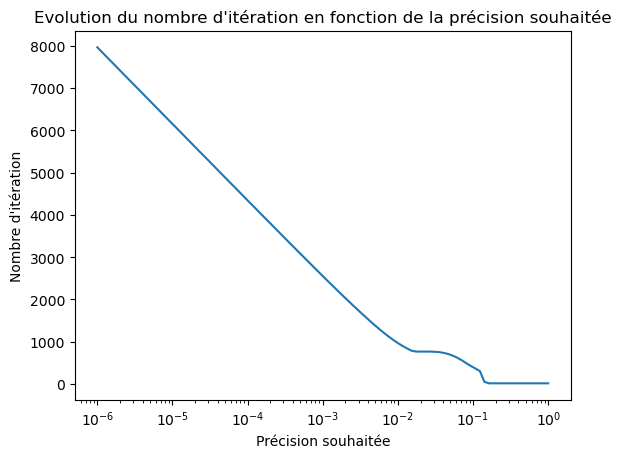

```python
import matplotlib.pyplot as plt
prec_list = [10**(-i) for i in np.linspace(0, 6, num=100)]
prec_result = [gradient_ls(f2.sim , x0 , i , ITE_MAX )[2] for i in prec_list]
#print(prec_result)
#plt.yscale('log')
plt.xscale('log')
plt.title("Evolution du nombre d'itération en fonction de la précision souhaitée")
plt.xlabel("Précision souhaitée")
plt.ylabel("Nombre d'itération")
plt.plot(prec_list, prec_result)
```

Pour les précisions supérieurs à 0.2, le nombre d'itération semble constant et vaut 1. On a une précision demandée assez grande pour tomber sur une valeur de gamma respectant la précision à la première itération.

## Exercice 5. Quasi Newton

Nous avons maintenant une méthode pour choisir un bon pas, nous allons à présent calculer une bonne direction.

Pour une fonction $f$ differentiable, les méthodes de Quasi-Newton construisent successivement une approximation $W_k$ de l'inverse de la Hessienne de la fonction et utilisent la direction $-W_k\nabla f(x_k)$.

**BFGS.** (Broyden-Fletcher-Goldfarb-Shanno, 1970) L'algorithme BFGS consiste à réaliser l'itération $$ x_{k+1}=x_k - \gamma_k W_k \nabla f(x_k)$$ où $\gamma_k$ est donné par la recherche linéaire de Wolfe et la matrice symmétrique définie positive $W_k$ est calculée par la formule de récurrence $$ W_{k+1}=W_k - \frac{s_k y_k^T W_k+W_k y_k s_k^T}{y_k^T s_k} +\left[1+\frac{y_k^T W_k y_k}{y_k^T s_k}\right]\frac{s_k s_k^T}{y_k^T s_k} $$ avec $s_k=x_{k+1}-x_{k}$ et $y_k=\nabla f(x_{k+1}) - \nabla f(x_{k})$.

Le schéma général d'une méthode de quasi-Newton est alors :

- avec l'itéré initial $x_0$, se donner une matrice initiale $W_0$ symétrique définie positive;
- connaissant le gradient $\nabla f(x_k)$, calculer la direction $d_k=-W_k \nabla f(x_k)$;
- calculer le pas $\gamma_k$ par recherche linéaire de Wolfe;
- connaissant le nouvel itéré $x_{k+1}$, appeler le simulateur et calculer la nouvelle matrice $W_{k+1}$.

> Implémenter la méthode BFGS et la tester sur la fonction $f_2$.

*Indication: utiliser la fonction `np.outer(a,b)` to compute $ab^T$.*

```python
import custom_optim
reload(custom_optim)
from custom_optim import Wolfe_line_search


import numpy as np
import timeit

def bfgs(sim , x0 , PREC , ITE_MAX, alpha ):
    x = np.copy(x0)
    x_tab = np.copy(x)
    f,g =  sim(x0)
    ####################
    # A COMPLETER

    k=0
    W = np.identity(np.shape(x_tab)[0]) * alpha

    while k < ITE_MAX and np.linalg.norm(g) > PREC:

        d = - W.dot(g)
        gamma = Wolfe_line_search(sim,x,d)

        if(gamma is None):
            print("method did not converge.")
            break

        next_x = x + gamma*d

        x_tab = np.vstack((x_tab,next_x)) # you may build x_tab by stacking vertically current x values

        next_f, next_g = sim(next_x)

        s = next_x - x
        y = next_g - g
        Wy = W.dot(y)

        yTs = np.transpose(y).dot(s)


        matrix_1 = (np.outer(s, Wy) + np.outer(Wy,s)) / yTs
        matrix_2 = (1 + np.transpose(Wy).dot(y)/yTs) * np.outer(s,s)/yTs

        W = W - matrix_1 + matrix_2
        f,g = next_f, next_g
        x = next_x

        k+=1
    ####################
    return x,x_tab,k
```

```python
import sim_f2 as f2
reload(f2)


#### Parameter we give at our algorithm
PREC    = 1e-6                    # Sought precision
ITE_MAX = 10000                      # Max number of iterations
x0      = np.array( [ -1 , 1.2] )    # Initial point

x,x_tab,nb_iter =  bfgs(f2.sim , x0 , PREC , ITE_MAX , 1)
```

```
importing notebook from sim_f2.ipynb
```

> Tracer les itérées sur les lignes de niveau de la fonction par la fonction `level_points_plot`.

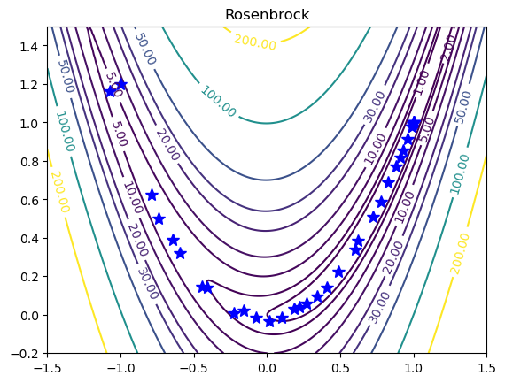

```
the minimum is at ( 0.9999999999931527 , 0.9999999999883968 ).
the algorithm converge in 34 iterations.
```

```python
import plotLib
reload(plotLib)
from plotLib import *
%matplotlib inline

level_points_plot( f2.sim , x_tab ,f2.x1_min,f2.x1_max,f2.x2_min,f2.x2_max,f2.nb_points, f2.levels , f2.title )
print("the minimum is at (",x[0], ",", x[1], ").")
print("the algorithm converge in", nb_iter, "iterations.")
```

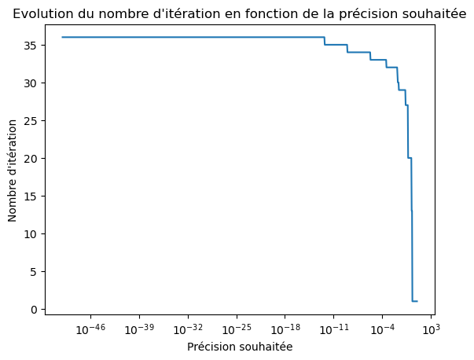

```
Le nombre d'itération pour avoir une précision de 1e-100000000000 est de 36
```

```python
import matplotlib.pyplot as plt
prec_list = [10**(-i) for i in np.linspace(-1, 50, num=1000)]
#ls_result = [gradient_ls(f2.sim , x0 , i , ITE_MAX )[2] for i in prec_list]
bfgs_result = [bfgs(f2.sim , x0 , i , ITE_MAX , 1)[2] for i in prec_list]

#print(bfgs_result)
#plt.yscale('log')
plt.xscale('log')
#plt.plot(prec_list, ls_result)
plt.title("Evolution du nombre d'itération en fonction de la précision souhaitée")
plt.xlabel("Précision souhaitée")
plt.ylabel("Nombre d'itération")
plt.plot(prec_list, bfgs_result)
plt.show()
print("Le nombre d'itération pour avoir une précision de 1e-100000000000 est de",bfgs(f2.sim , x0 , 1e-100000000000 , ITE_MAX , 1)[2])
```

On peut remarquer que l'algorithme de Broyden-Fletcher-Goldfarb-Shanno demande beaucoup moins d'itération que celui de recherche linéaire. Pour une précision de 1e-6, on 7965 itérations pour la recherche linéaire contre 34 pour l'algorithme bfgs. Soit 234 fois moins d'itérations

On peut aussi remarquer que le nombre d'itération semble converger vers une valeur de 36 pour des précisions très petites. Cela peut aussi être dû à un problème d'arrondi sur la précision.

[output not shown]

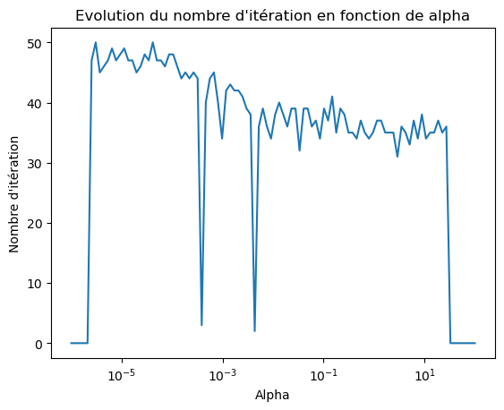

```
Valeur Remarquable
Pour alpha =  0.0003853528593710527 nb itération = 3
Pour alpha =  0.004328761281083053 nb itération = 2
```

```python
import matplotlib.pyplot as plt
PREC    = 1e-60
alpha_list = [10**(-i) for i in np.linspace(-2, 6, num=100)]
bfgs_result = [bfgs(f2.sim , x0 , PREC , ITE_MAX , i)[2] for i in alpha_list]
plt.xscale('log')
plt.title("Evolution du nombre d'itération en fonction de alpha")
plt.xlabel("Alpha")
plt.ylabel("Nombre d'itération")
plt.plot(alpha_list, bfgs_result)
plt.show()
print("Valeur Remarquable")
print("Pour alpha = ",alpha_list[67], "nb itération =", bfgs_result[67])
print("Pour alpha = ",alpha_list[54], "nb itération =", bfgs_result[54])
```

En ajoutant un coefficient $\alpha$ à la matrice identité, comme dans le cours, on peut voir que ce coefficient positif peut avoir une influence sur le nombre d'itération.

Pour une valeur de $\alpha$ supérieur approximativement à 30 ou inférieur à 1e-6, la méthode ne converge pas. Entre ces deux valeurs on peut remarquer une tendance, une diminution du nombre d'itération plus le $\alpha$ est élevé.

Nous avons aussi deux valeurs de $\alpha$ pour lesquelles le nombre d'itération est vraiment petit. On suppose que ce sont des valeurs permettant d'optimiser seulement cette fonction.

## Bonus: Newton

> Créer dans les fichiers `sim_f1.ipynb` et `sim_f2.ipynb` un nouveau simulateur retournant également la Hessienne des fonctions respectives. Implémenter la méthode de Newton $$ x_{k+1} = x_k - [\nabla^2f(x_k)]^{-1} \nabla f(x_k)$$ et comparer avec Quasi-Newton.

```python
import start
from imp import reload

import sim_f2 as f2
reload(f2)

import sim_f1 as f1
reload(f1)
```

```
importing notebook from sim_f2.ipynb
importing notebook from sim_f1.ipynb
```

```
<module 'sim_f1' from 'sim_f1.ipynb'>
```

```python
import numpy as np
import timeit

def newton(sim , x0 , PREC , ITE_MAX ):
    x = np.copy(x0)
    x_tab = np.copy(x)
    f,g,h = sim(x0)
    ####################
    k=0
    while k < ITE_MAX and np.linalg.norm(g) > PREC:
        d = np.linalg.solve(h, -g) #On résoud un système afin d'avoir un inversion matricielle à moindre coup.
        x = x + d
        x_tab = np.vstack((x_tab,x))
        f,g,h = sim(x)
        k+=1
    ####################
    return x,x_tab,k
```

```python
import sim_f2 as f2
reload(f2)


#### Parameter we give at our algorithm
PREC    = 1e-6                    # Sought precision
ITE_MAX = 10000                      # Max number of iterations
x0      = np.array( [ -1 , 1.2] )    # Initial point

x,x_tab,nb_iter =  newton(f2.sim_hessian , x0 , PREC , ITE_MAX )
```

```
importing notebook from sim_f2.ipynb
```

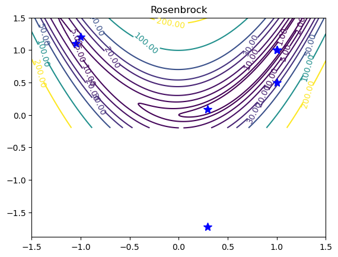

```
the minimum is at ( 0.9999999999999998 , 0.9999999999999997 ).
the algorithm converge in 7 iterations.
```

```python
import plotLib
reload(plotLib)
from plotLib import *
%matplotlib inline

level_points_plot( f2.sim , x_tab ,f2.x1_min,f2.x1_max,f2.x2_min,f2.x2_max,f2.nb_points, f2.levels , f2.title )
print("the minimum is at (",x[0], ",", x[1], ").")
print("the algorithm converge in", nb_iter, "iterations.")
```

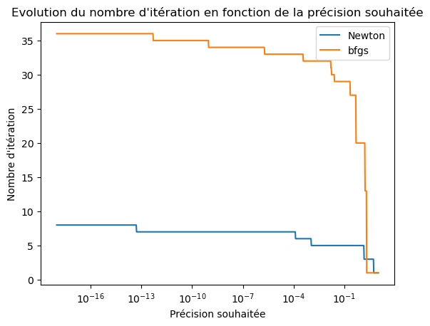

```python
prec_list = [10**(-i) for i in np.linspace(-1, 18, num=1000)]
#ls_result = [gradient_ls(f2.sim , x0 , i , ITE_MAX )[2] for i in prec_list]
bfgs_result = [bfgs(f2.sim , x0 , i , ITE_MAX , 1)[2] for i in prec_list]
newton_result = [newton(f2.sim_hessian , x0 , i , ITE_MAX)[2] for i in prec_list]
#print(bfgs_result)
#plt.yscale('log')
plt.xscale('log')

plt.title("Evolution du nombre d'itération en fonction de la précision souhaitée")
plt.xlabel("Précision souhaitée")
plt.ylabel("Nombre d'itération")
plt.plot(prec_list, newton_result, label="Newton")
plt.plot(prec_list, bfgs_result,label="bfgs")
plt.legend()
plt.show()
```

On peut voir que l'algorithme de Newton à une évolution similaire du nombre d'itération que l'algorithme bfgs, cependant pour les petites valeurs de précision on semble converger vers une valeur plus petite que celle de bfgs, (~7). On gagne donc un facteur 5 en utilisant cet algorithme comparé à bfgs pour de très petite valeur.

Cependant l'algorithme de Newton semble avoir besoin d'un seuil de précision de départ plus élevé